# JP32 (ActD CP mouse) RNA preprocessing

Created on: January 11, 2022

```r
suppressPackageStartupMessages(library(dplyr))
suppressPackageStartupMessages(library(Seurat))
suppressPackageStartupMessages(library(SingleR))
suppressPackageStartupMessages(library(scater))
suppressPackageStartupMessages(library(scran))
suppressPackageStartupMessages(library(clustree))
suppressPackageStartupMessages(library(ggplot2))
suppressPackageStartupMessages(library(VennDiagram))
suppressPackageStartupMessages(library(ggrepel))
suppressPackageStartupMessages(library(cowplot))
```

```r
# increase heap size of java for handling java.lang.OutOfMemoryError while writing to excel file. The value 8000 is the number of megabytes of RAM to allow for the Java heap; it can be replaced with any value you like
options(java.parameters =c("-XX:+UseConcMarkSweepGC", "-Xmx30000m"))
path<-"~/Documents/Kia/Munro_CPepi_review/"
sample.names<-c("JP32")
metadata=read.csv(paste0(path,"data/annot_JP3233.csv"))
source("~/Documents/scripts/preprosessing_May.2020.R")
gene.markers<-read.csv("~/Documents/gene_protein_lists/markergenes_mouse.csv")
cols.use=c("brown1","goldenrod3","goldenrod1","darkorchid","mediumpurple","darkolivegreen1","magenta","dodgerblue","turquoise3","lightblue","gold4","coral","violetred","grey","green3","goldenrod1","palevioletred", "seagreen", "red","yellow", "brown3", "grey30", "pink", "bisque", "yellowgreen", "grey30","lightgreen","lightblue","violet","purple")
```

Read in the raw unfiltered data to SingleCellExperiment R object

```
[1] \JP32\
[1] 32285  2391
```

`r`r rm(expr.mat)

Get mitochondrial genes and calculate QC metrics per cell

```
[1] 13
```

#### Find outliers for total UMI counts, number of genes and % mitohondrial genes per cell based on the median absolute deviation (MAD) (scater function)

- UMI counts per cell

```
 JP32
Outliers: 18
```

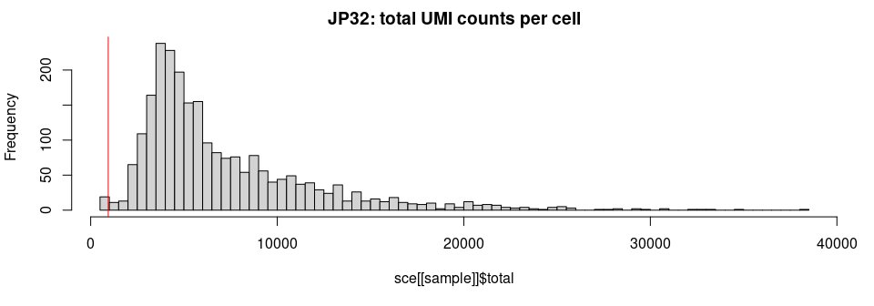

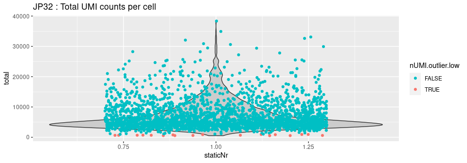

- Number of genes per cell

```
 JP32
Outliers: 30
```

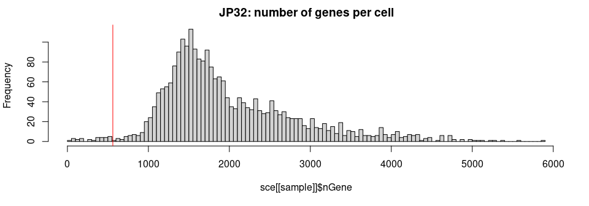

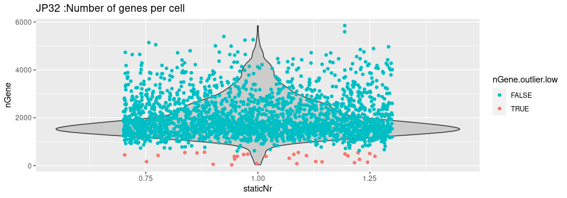

- % mitohondrial genes per cell

```
 JP32
Outliers: 46
```

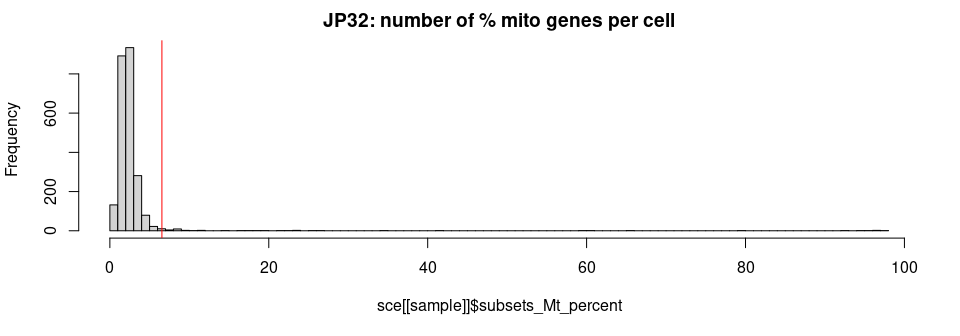

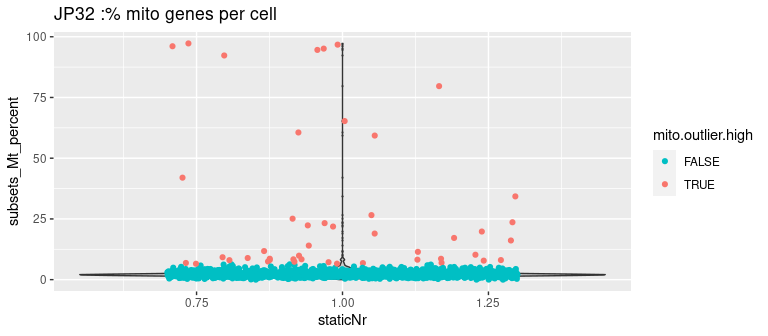

#### Overlap of cells, outliers for UMI counts, # genes and % mitochodrial genes per cell

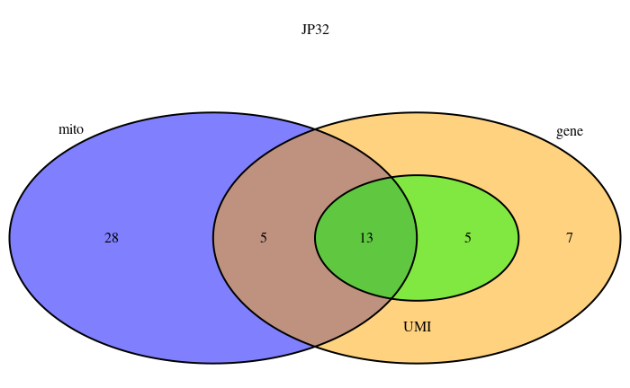

`r`r rm(v)

### Filter the outlier cells

```
[1] \JP32\
[1] \58 cells to be removed\
```

#### Violin plots after filtering

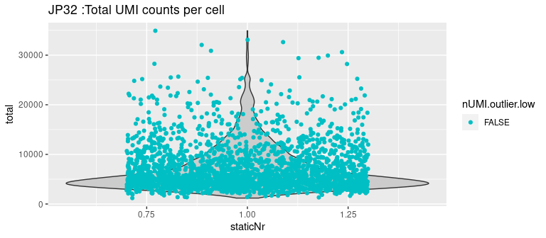

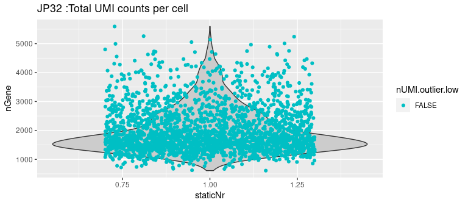

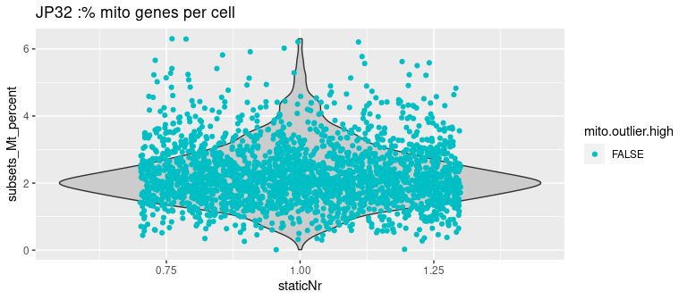

Number of genes/cells after filtering

`r`r sce_clean=list() for ( sample in sample.names) { cells.to.keep= ! (sce[[sample]]$mito.outlier.high | sce[[sample]]$nGene.outlier.low | sce[[sample]]$nUMI.outlier.low) sce_clean[[sample]]<-sce[[sample]][, cells.to.keep] print(sample) print(dim(sce_clean[[sample]])) }

```
[1] \JP32\
[1] 32285  2333
```

#### Filter the lowly abundant genes

To check whether the chosen threshold is suitable, we examine the distribution of log-means across all genes. The peak represents the bulk of moderately expressed genes while the rectangular component corresponds to lowly expressed genes. The filter threshold should cut the distribution at some point along the rectangular component to remove the majority of low-abundance genes.

`r`r ave.counts=list() for ( sample in sample.names) { ave.counts[[sample]] <- rowMeans(as.matrix(counts(sce_clean[[sample]]))) }

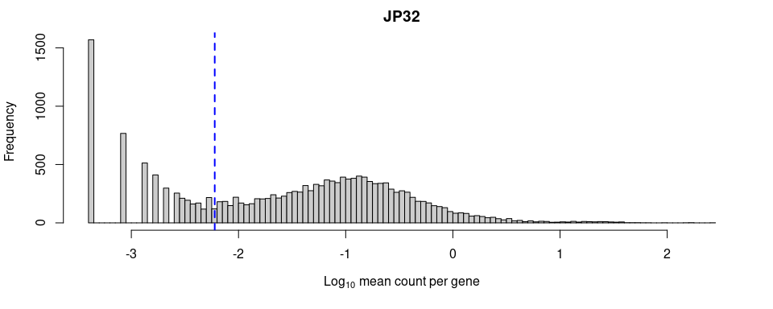

Number of genes to keep

`r`r for ( i in 1: length(sample.names)) { print(sample.names[i]) rowData(sce_clean[[sample.names[i]]])$usegenes<-ave.counts[[sample.names[i]]]>thresh[i] print(table(rowData(sce_clean[[sample.names[i]]])$usegenes)) }

```
[1] \JP32\

FALSE  TRUE
20002 12283
```

Remove outlier genes and re-calculate QC metrics after filtering

```
[1] 13
```

Doubletcells() - identifying doublets at a cell level, by simulating artificial doublets (scran function)

`r`r for ( sample in sample.names) { sce_clean[[sample]]$Doublet.score.scran<- doubletCells(sce_clean[[sample]]) }

`r`r for ( sample in sample.names) { if(!identical(rownames(colData(sce_clean[[sample]])),colnames(counts(sce_clean[[sample]])))) print(paste(sample, : cell names are not the same in colData and in the count matrix)) }

Convert to Seurat object

`r`r rm(sce) rm(sce_clean) rm(meta.data.keep) rm(counts) rm(ave.counts)

`r`r seur_clean<-seur_clean[[1]]

### Data normalization, identification of highly variable genes, scaling and PCA dimensionality reduction

`r`r seur_clean <- NormalizeData(seur_clean,verbose = F) seur_clean <- FindVariableFeatures(seur_clean,verbose=F) seur_clean <- ScaleData(seur_clean,verbose = F) seur_clean <- RunPCA(seur_clean, features = VariableFeatures(seur_clean),verbose=F)

#### Determine the a number of PCs to include for downstream analysis

A heuristic method to help us with that generates an ‘Elbow plot’: a ranking of principle components based on the percentage of variance explained by each one

`r`r ElbowPlot(object = seur_clean,ndims =50)

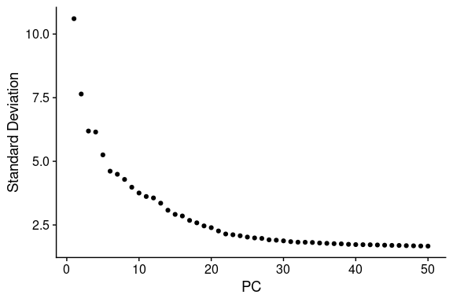

Another useful plot is a heatmap of the top genes driving each PC

`r`r DimHeatmap(seur_clean, dims = 20:34, cells = 5000, balanced = TRUE)

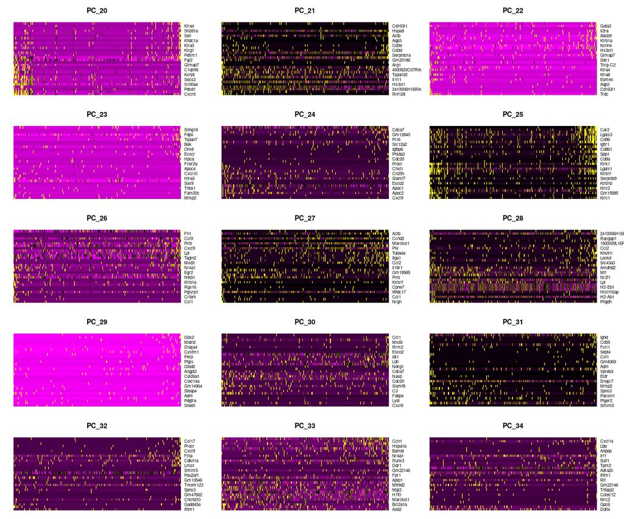

Both cells and features are ordered according to their PCA scores. Setting “cells” to a number plots the ‘extreme’ cells on both ends of the spectrum, which dramatically speeds plotting for large datasets.

Selection of the top 30 PCs:

`r`r dims.use<-30

#### Run non-linear dimensional reduction (UMAP) for visualisation of the data

CD45 expression

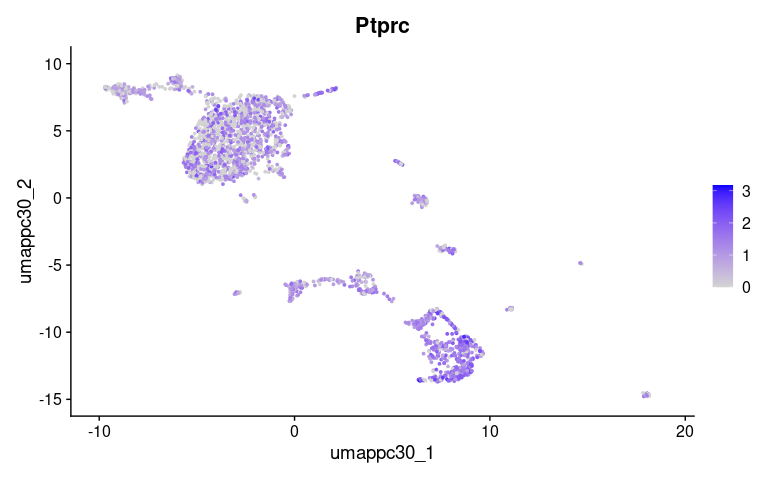

XIST expression

```
Error: None of the requested features were found: Xist in slot data
```

#### Annotate cell types for each cell using the SingleR package and the immgen reference (microarray profiles of pure mouse immune cells from the project of the same name (Heng et al. 2008 - http://www.immgen.org/ )

`r`r immgen <- ImmGenData()

`r`r seur_clean$singler.immgen.main<-singler.res[rownames(seur_clean[[]]),.labels]

`r`r rm(singler.res)

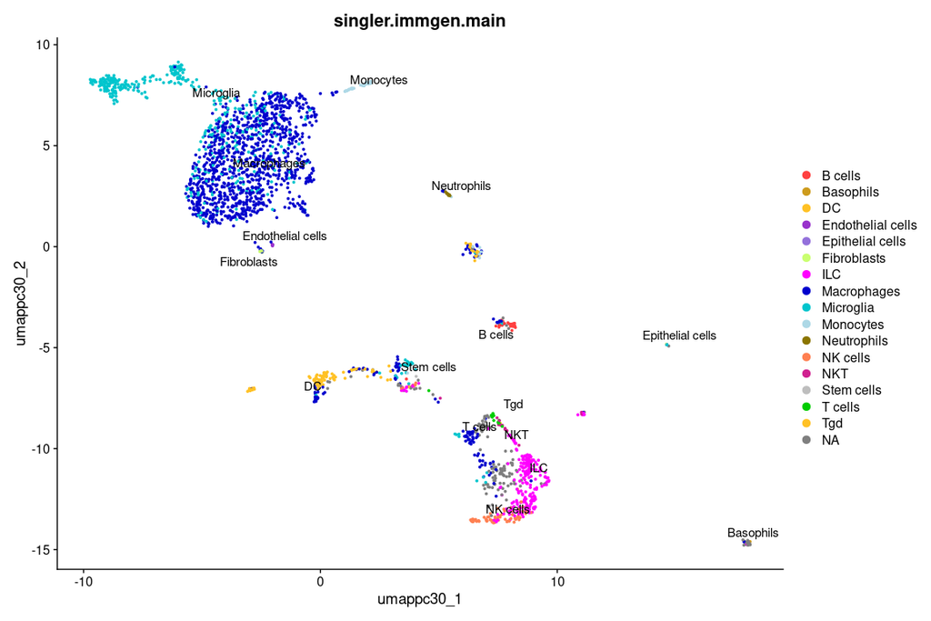

Visualize QC metrics per cell

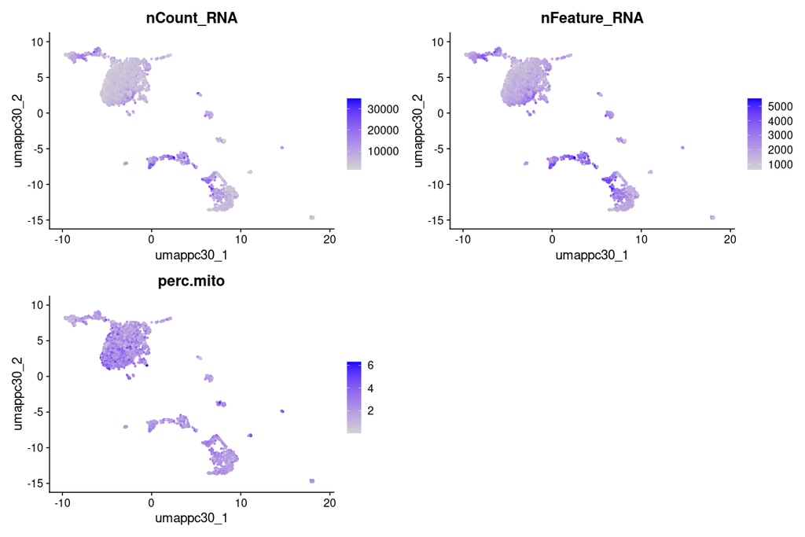

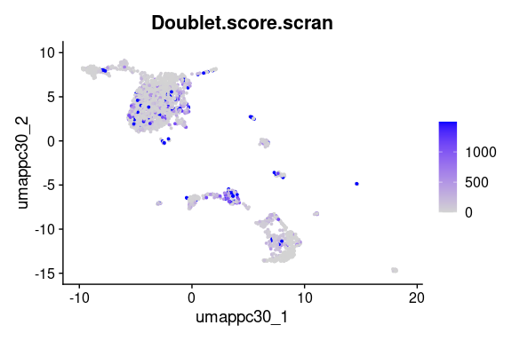

### Add metadata from the Brain immune atlas (https://www.brainimmuneatlas.org/data_files/toDownload/annot_JP3233.csv)

```
[1] 2333
```

`r`r nrow(metadata)

```
[1] 1977
```

`r`r length(intersect(rownames(metadata), colnames(seur_clean)))

```
[1] 1974
```

`r`r metadata=metadata[intersect(rownames(metadata), colnames(seur_clean)),] seur_clean$Manuscript_cell_type=NA seur_clean$Manuscript_cell_type[rownames(metadata)]=metadata$cluster

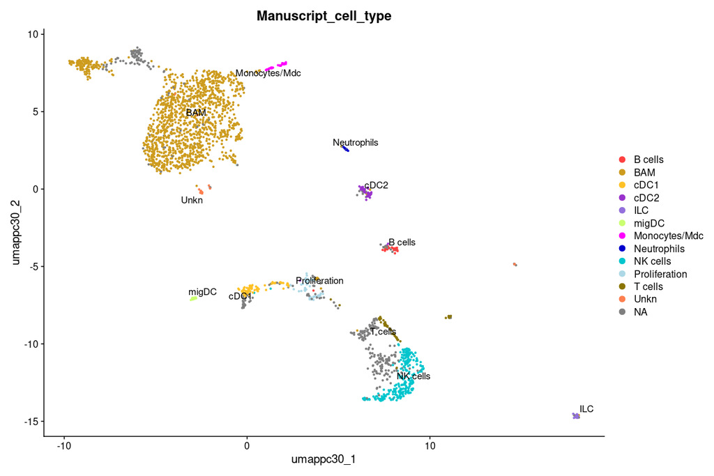

### Clustering with varying the resolution

#### Plot of a clustering tree showing the relationship between clusterings at different resolutions. (using the clustree package)

One helpful plot for choosing a resolution is a clustering tree. To build a clustering tree we need to look at how cells move as the clustering resolution is increased. Each cluster forms a node in the tree and edges are constructed by considering the cells in a cluster at a lower resolution (say k=2) that end up in a cluster at the next highest resolution (say k=3). By connecting clusters in this way we can see how clusters are related to each other, which are clearly distinct and which are unstable. Extra information about the cells in each node can also be overlaid in order to help make the decision about which resolution to use.

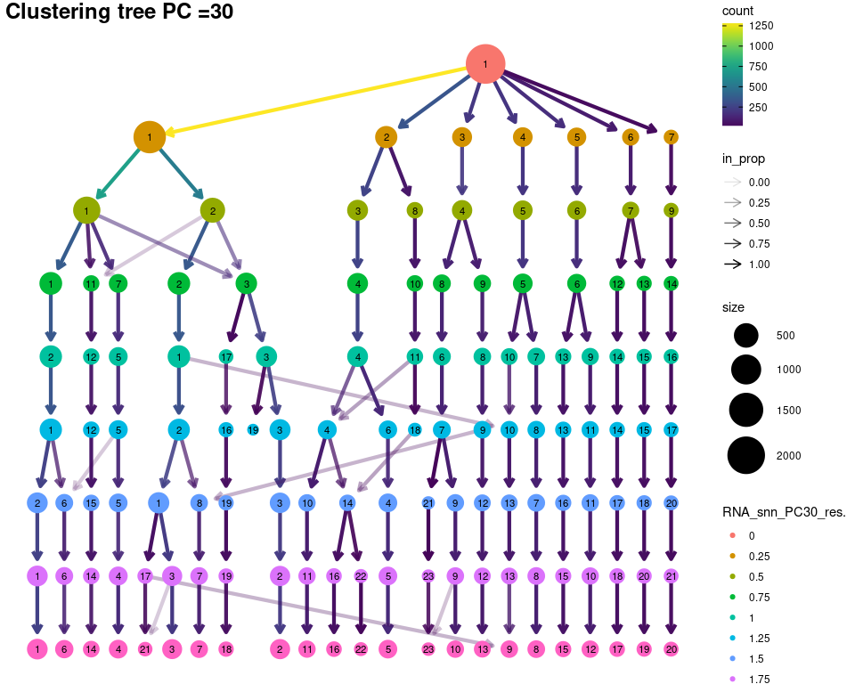

The clustering seems to be relatively stable until resolution 1.25

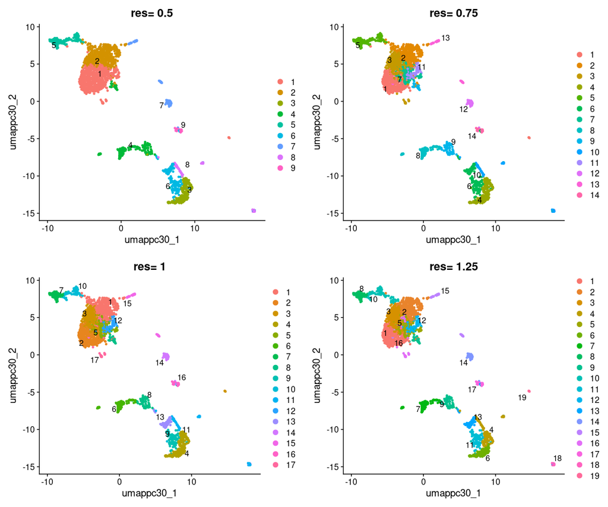

### Let’s find differentially expressed genes per cluster for resolution=1

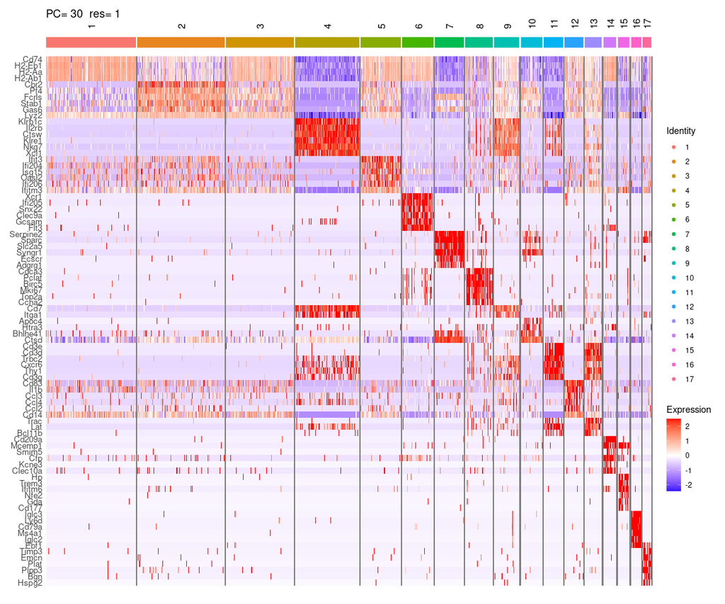

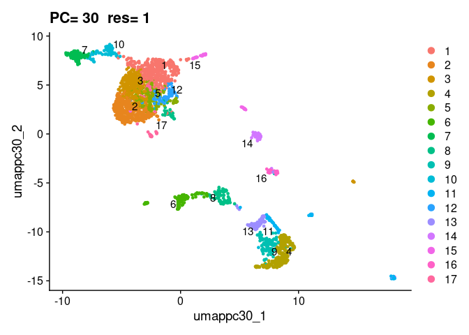

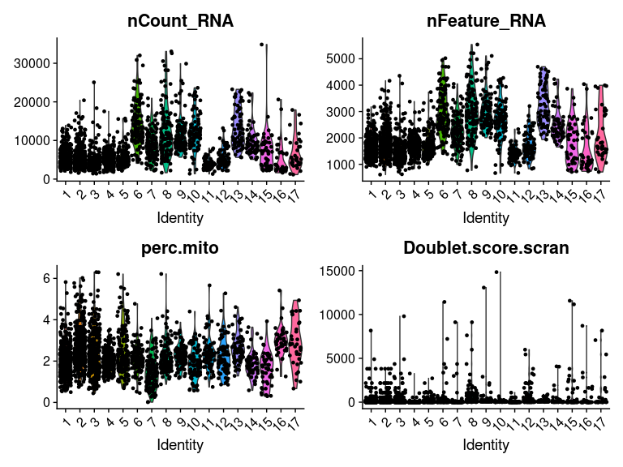

Monocytic/Macrophage markers

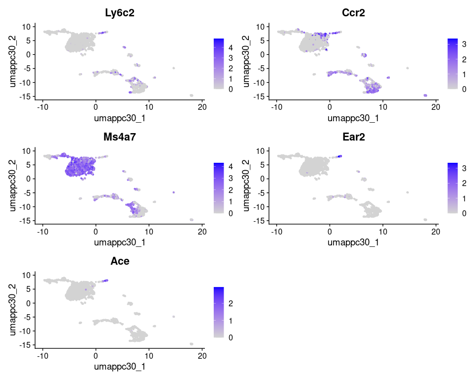

Microglia markers

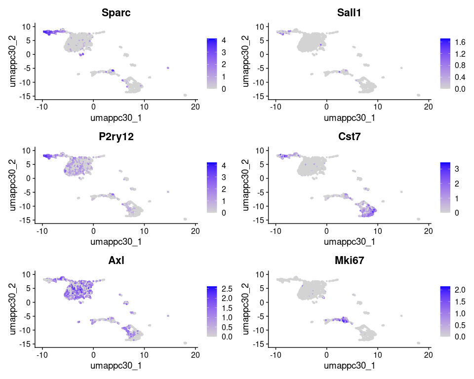

DC markers

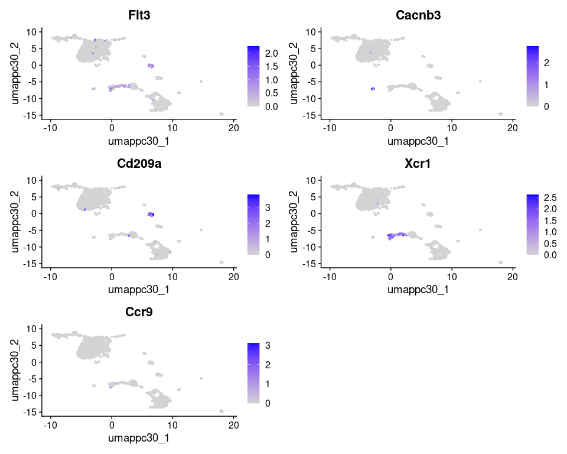

Granulocyte markers